# LAB 3

Author

Ashkan Taghavi

# Data Set

**1. Loading Packages**

```r
library(tidyverse)
library(here)
```

## Summary

**2. Summary & Provide a brief overview (2-4 sentences) of the data set.**

```r
hipHopData <- read_csv(here("Week 3", "Lab 3", "hiphop.csv"))
```

This study takes a deeper look at African-American English (AAE) by asking students from the University of Minnesota familiarity of different vocabulary words. All the data seems to be in either characters, or numbers. There also seems to be some people in the study where key columns are not recorded for, like city being 0. There is overall 10,752 rows and 38 variables in total.

**3. Rows of this data set**

```r
summary(hipHopData)
hipHopData |>
  count(word, subj) |>
  nrow()
```

[output not shown]

There are 10,752 rows in this data set. This is because there are 168 people and 64 words. Therefore for each word, 168 people (or rows) will be answering it.

## Cleaning the Data

**4. Missing values for some of the variables were replaced with other values. How were missing values replaced? What do you believe are some benefits and drawbacks of doing this?**

```r
hipHopData |>
  filter(city == 0, county == 0)
```

```
# A tibble: 384 × 38
   word    subj  sex     age ethnic  city county  intl vocal class…¹  folk  rock
   <chr>   <chr> <chr> <dbl> <chr>  <dbl>  <dbl> <dbl> <dbl>   <dbl> <dbl> <dbl>
 1 [to be… p145  Male     18 white      0      0     0     0       0     0    15
 2 [to be… p147  Fema…    20 asian      0      0     0     0       4     0     0
 3 [to be… p11   Fema…    18 asian      0      0    15     0       0     0     0
 4 [to be… p43   Fema…    18 asian      0      0     6     0       0     0     0
 5 [to be… p135  Fema…    18 asian      0      0     0     0       3     0     0
 6 [to be… p81   Fema…    18 asian      0      0     0     0       2     0     0
 7 5-0     p145  Male     18 white      0      0     0     0       0     0    15
 8 5-0     p147  Fema…    20 asian      0      0     0     0       4     0     0
 9 5-0     p11   Fema…    18 asian      0      0    15     0       0     0     0
10 5-0     p43   Fema…    18 asian      0      0     6     0       0     0     0
# … with 374 more rows, 26 more variables: country <dbl>, pop <dbl>,
#   alternative <dbl>, hiphop <dbl>, unclassifiable <dbl>, countyBlack <dbl>,
#   jayz <dbl>, barkley <dbl>, boondocks <dbl>, monique <dbl>, bieber <dbl>,
#   asianMove <dbl>, blackMove <dbl>, hispanicMove <dbl>, nativeMove <dbl>,
#   SAAMEMove <dbl>, whiteMove <dbl>, blackWeekly <dbl>, jayz1 <dbl>,
#   boondocks1 <dbl>, familiarity <dbl>, trial <dbl>, fam1 <dbl>,
#   popularityScore <dbl>, numPreferredArtists <dbl>, …
```

It seems that some of the variables were replaced with 0 instead of NA values, such as some subjects data in city and county. This could be seen as beneficial because they would still represent specific points in the data set, without potentially needing to remove them. A drawback, however, is that when using summary statistics, the points would still be accounted for, which instead might drop down the mean/median without meaning to do so.

### Reflection

Originally, I answered this question saying that the dataset used zero’s to replace missing values. However, upon further review, there were more ways that missing values were replaced within this dataset. Another way missing values were replaced was with the mean values. Looking at the documentation of the dataset, it stated that with the __Move variables, contained missing values that were replaced with mean values in these variables. Also blackWeekly, which was the number of strong and weak tie to African-Americans also had missing values that were replaced with mean values. This can be beneficial as it allows you to still have representation of these points to when doing analysis, however one drawback is that lead to innacurate information being represented within the dataset.

**5. Clean the data set**

```r
# code chunk for Q5
hiphop_clean <- hipHopData |>
  mutate(across(c(sex, ethnic, jayz1, fam1, boondocks1), .fns = as.factor
                )) |>
  filter(city != 0,
         county != 0,
         countyBlack != 0
         )
```

# Data Summaries

**6. How many unique AAE words were studied in this data set?**

```r
# code chunk for Q6
hipHopData |>
  distinct(word) |>
  nrow()
```

```
[1] 64
```

There are 64 unique AAE words that were studied in this data set.

**7. Make a new variable that re-categorizes `ethnic` into only two groups, “white” and “non-white”, to simplify your data.**

```r
# code chunk for Q7
hiphop_clean <- hiphop_clean |>
  mutate(ethnic1 = if_else(ethnic == 'white', 'white', 'non-white'),
         ethnic1 = as.factor(ethnic1)
  )
```

**8. It is fairly common for researchers to collapse ethnic or racial categories similar to what you just did. What are some issues with representing the data in this way?**

Here is my answer to this question:

Collapsing ethnic or racial categories into larger groups can lead to a loss of information and mask important differences among subgroups within those categories. This can cause many issues, however here are two issues I believe are important to note:

Bias: The decision to collapse categories may be influenced by implicit biases or cultural assumptions that do not accurately reflect the diversity within the larger group.

Inaccurate conclusions: Collapsing categories can lead to inaccurate conclusions about the experiences of certain groups. For example, if you collapse all Asian Americans into a single category, you may miss important differences between subgroups such as Chinese Americans and Vietnamese Americans.

**9. What are the demographics of the people in this study? Investigate the variables `sex`, `age`, and `ethnic` and summarize your findings in 1-3 complete sentences.**

```r
# code chunk for Q9
hiphop_clean |>
  distinct(subj, age, ethnic, sex) |>
  summary()
```

```
     subj               sex           age             ethnic
 Length:159         Female:109   Min.   :16.00   white   :133
 Class :character   Male  : 50   1st Qu.:18.00   asian   : 14
 Mode  :character                Median :19.00   african :  5
                                 Mean   :20.12   indian  :  2
                                 3rd Qu.:20.00   biracial:  1
                                 Max.   :48.00   black   :  1
                                                 (Other) :  3
```

In this data set, there seems to be an age range between 16 and 48 with the median being 19. For ethnicity, there seems to be a majority white with 133 students, followed by asian with 14 students. For sex, the class seems to be predominately female with 109 students, followed by male with 50 students.

**10. Two plots that display the demographic information of the subjects in this study.**

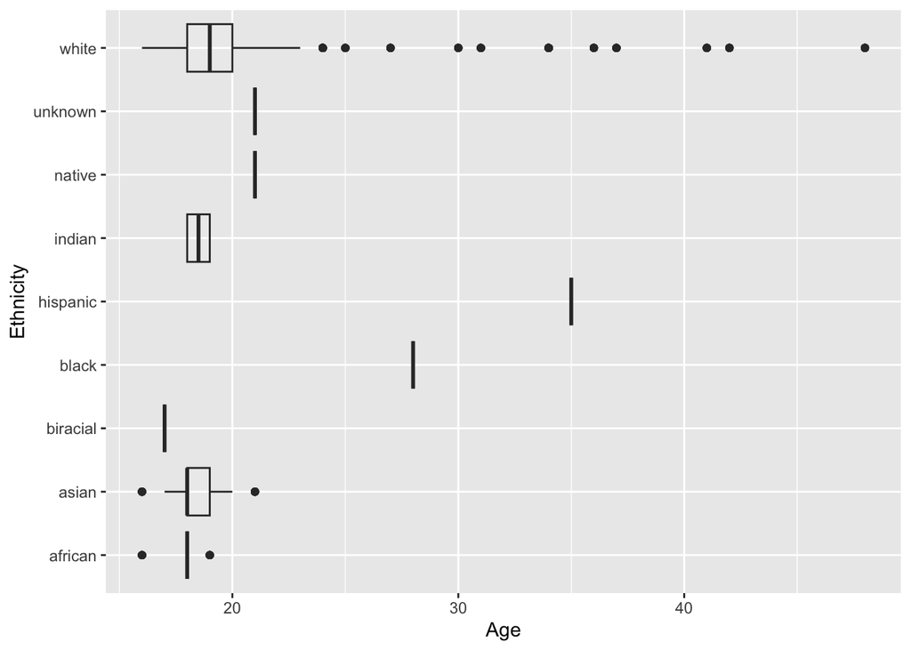

```r
# code chunk for Q10
library(ggridges)
hiphop_clean |>
  ggplot(data = hiphop_clean,
       mapping = aes(x = age,
                     y = ethnic,
                     )) +
  geom_boxplot(alpha = 0.1) +
  labs(x = "Age", y = "Ethnicity")
```

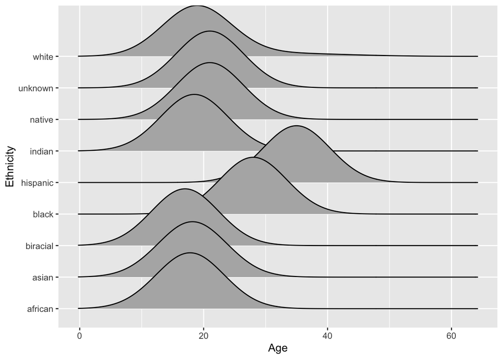

```r
hiphop_clean |>
  ggplot(mapping = aes(x = age,
                                   y = ethnic,
                                   )) +
  geom_density_ridges(panel_scaling = FALSE)  +
                    labs(x = "Age",
                         y = "Ethnicity")
```

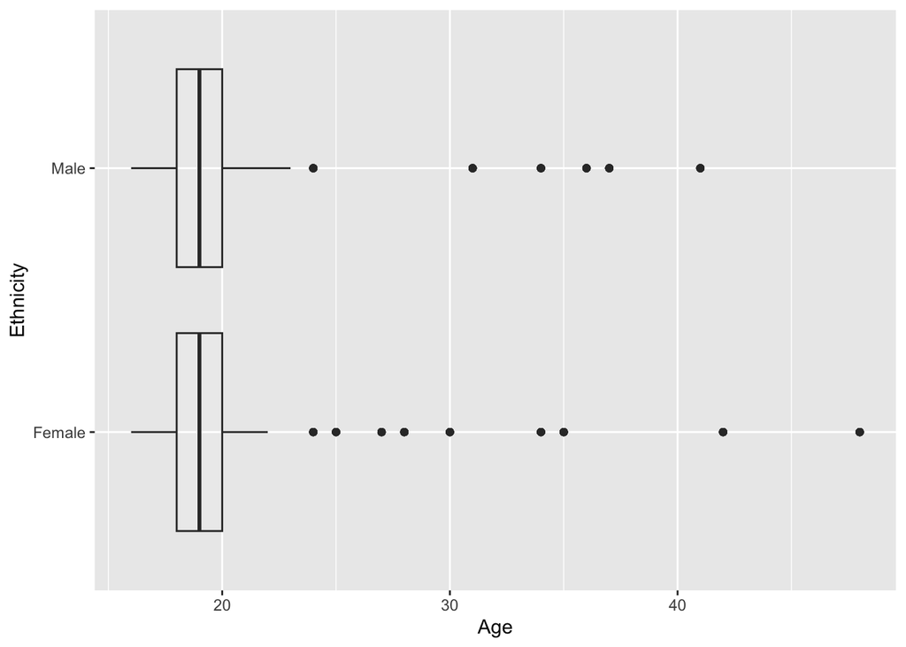

```r
# Revised Code:
hiphop_clean |>
  ggplot(data = hiphop_clean,
       mapping = aes(x = age,
                     y = sex,
                     )) +
  geom_boxplot(alpha = 0.1) +
  labs(x = "Age", y = "Ethnicity")
```

### Reflection

Initially, I made two different types of graphs that showed showed/contaiend the same demographic information. After reading your comments, I realized that I needed to make a second graph that showed a new/different descriptive demographic of the data set that could provide more useful information. I then added a new box plot that showed information on the ages of the subjects between males and females, which I believe is useful it gives further context of between sample of males and females. We know that dataset subject are made up of students, but this box plots shows (not taking into account the outliars) that the age of males and females in the data set are very similar and comparable.

## Familiar words

For each demographic group listed below, determine which word(s) in this study was (were) the most **and** least familiar on average.

**11. People below the age of 20.**

```r
# code chunk for Q11
hiphop_clean |>
  filter(age < 20) |>
  group_by(word) |>
  summarize(fammean = mean(familiarity)) |>
  slice_max(fammean)
```

```
# A tibble: 1 × 2
  word         fammean
  <chr>          <dbl>
1 off the hook    4.53
```

Max: **off the hook**

```r
hiphop_clean |>
  filter(age < 20) |>
  group_by(word) |>
  summarize(fammean = mean(familiarity)) |>
  slice_min(fammean)
```

```
# A tibble: 1 × 2
  word   fammean
  <chr>    <dbl>
1 domino    1.02
```

Min: **domino**

**12. Non-white women.**

```r
# code chunk for Q12
hiphop_clean |>
  filter(sex == 'Female' &
           ethnic1 == 'non-white') |>
  group_by(word) |>
  summarize(fammean = mean(familiarity)) |>
  slice_max(fammean)
```

```
# A tibble: 1 × 2
  word    fammean
  <chr>     <dbl>
1 feel me    4.37
```

Max: feel me

```r
hiphop_clean |>
  filter(sex == 'Female' &
       ethnic1 == 'non-white') |>
  group_by(word) |>
  summarize(fammean = mean(familiarity)) |>
  slice_min(fammean)
```

```
# A tibble: 5 × 2
  word              fammean
  <chr>               <dbl>
1 break someone out       1
2 domino                  1
3 dukey rope              1
4 plex                    1
5 rollie                  1
```

Min: **break someone out, domino, dukey rope, plex, rollie**

**13. White men above the age of 30.**

```r
# code chunk for Q13
hiphop_clean |>
  filter(sex == 'Male' &
       ethnic1 == 'white' &
       age > 30) |>
  group_by(word) |>
  summarize(fammean = mean(familiarity)) |>
  slice_max(fammean)
```

```
# A tibble: 1 × 2
  word  fammean
  <chr>   <dbl>
1 5-0       4.2
```

Max: **5-0**

```r
hiphop_clean |>
  filter(sex == 'Male' &
       ethnic1 == 'white' &
       age > 30) |>
  group_by(word) |>
  summarize(fammean = mean(familiarity)) |>
  slice_min(fammean)
```

```
# A tibble: 25 × 2
   word              fammean
   <chr>               <dbl>
 1 ay yo trip              1
 2 beezy                   1
 3 break someone out       1
 4 catch the vapors        1
 5 crossroads              1
 6 crump                   1
 7 dap                     1
 8 dollar cab              1
 9 domino                  1
10 duckets                 1
# … with 15 more rows
```

## Study Subjects

**14. Determine which subject you believe is secretly Bieber, justify your answer.**

```r
# code chunk for Q14
# Revised code
hiphop_clean |>
  filter(sex == 'Male',
       ethnic == 'white',
       age >= 17,
       age <= 23,
       city >= 10000,
       city <= 60000) |>
  slice_max(bieber) |>
  group_by(subj) |>
  summarize()
```

```
# A tibble: 1 × 1
  subj
  <chr>
1 p17
```

```r
# Previous code before revision
# hiphop_clean |>
#   filter(sex == 'Male',
#        ethnic == 'white',
#        age >= 17,
#        age <= 23,
#        city >= 10000,
#        city <= 60000,
#        bieber >= 5) |>
#   group_by(subj) |>
#   summarize()
```

I would think that Justin Bieber would be person 17. Adjusting for the factors above, and using the bieber variable to get the most Bieber listener, the person who stood out was p17. However, it is odd he did not know all his songs (with a score 6).